# Customer Segmentation Decision

Ibeh Amaka

2023-10-01

Targeted Customer Campaigns Retail businesses want a targeted marketing campaign to increase sales and customer engagement. They have customer data, including annual income and spending scores. They need to decide how to segment their customer base effectively for the marketing campaign

#knitr::opts_chunk$set(echo = TRUE) #install all packages used # install.packages(“readr”) # install.packages(“tidyverse”) # install.packages(“tidyr”) # install.packages(“ggplot2”) # install.packages(“dylyer”) # install.packages(“data.table”) # install.packages(“cluster”) # install.packages(“plotly”)

Load the packages

load the dataset

```r
mall <- read_csv("Data/Mall_Customers.csv")
```

Performing EDA for this dataset

```r
#EDA
dim(mall)
```

```
## [1] 200   5
```

```r
##contains 200 observation and 5 variables
head(mall,10)
```

```
## # A tibble: 10 x 5
##    CustomerID Genre    Age `Annual Income (k$)` `Spending Score (1-100)`
##    <chr>      <chr>  <dbl>                <dbl>                    <dbl>
##  1 0001       Male      19                   15                       39
##  2 0002       Male      21                   15                       81
##  3 0003       Female    20                   16                        6
##  4 0004       Female    23                   16                       77
##  5 0005       Female    31                   17                       40
##  6 0006       Female    22                   17                       76
##  7 0007       Female    35                   18                        6
##  8 0008       Female    23                   18                       94
##  9 0009       Male      64                   19                        3
## 10 0010       Female    30                   19                       72
```

```r
tail(mall,10)
```

```
## # A tibble: 10 x 5
##    CustomerID Genre    Age `Annual Income (k$)` `Spending Score (1-100)`
##    <chr>      <chr>  <dbl>                <dbl>                    <dbl>
##  1 0191       Female    34                  103                       23
##  2 0192       Female    32                  103                       69
##  3 0193       Male      33                  113                        8
##  4 0194       Female    38                  113                       91
##  5 0195       Female    47                  120                       16
##  6 0196       Female    35                  120                       79
##  7 0197       Female    45                  126                       28
##  8 0198       Male      32                  126                       74
##  9 0199       Male      32                  137                       18
## 10 0200       Male      30                  137                       83
```

```r
sum(is.na(mall))
```

```
## [1] 0
```

```r
str(mall)
```

```
## spc_tbl_ [200 x 5] (S3: spec_tbl_df/tbl_df/tbl/data.frame)
##  $ CustomerID            : chr [1:200] "0001" "0002" "0003" "0004" ...
##  $ Genre                 : chr [1:200] "Male" "Male" "Female" "Female" ...
##  $ Age                   : num [1:200] 19 21 20 23 31 22 35 23 64 30 ...
##  $ Annual Income (k$)    : num [1:200] 15 15 16 16 17 17 18 18 19 19 ...
##  $ Spending Score (1-100): num [1:200] 39 81 6 77 40 76 6 94 3 72 ...
##  - attr(*, "spec")=
##   .. cols(
##   ..   CustomerID = col_character(),
##   ..   Genre = col_character(),
##   ..   Age = col_double(),
##   ..   `Annual Income (k$)` = col_double(),
##   ..   `Spending Score (1-100)` = col_double()
##   .. )
##  - attr(*, "problems")=<externalptr>
```

```r
#remove white spaces from column names
colnames(mall) <- gsub(" ", "", colnames(mall))
##rename columns
str(mall)
```

```
## spc_tbl_ [200 x 5] (S3: spec_tbl_df/tbl_df/tbl/data.frame)
##  $ CustomerID          : chr [1:200] "0001" "0002" "0003" "0004" ...
##  $ Genre               : chr [1:200] "Male" "Male" "Female" "Female" ...
##  $ Age                 : num [1:200] 19 21 20 23 31 22 35 23 64 30 ...
##  $ AnnualIncome(k$)    : num [1:200] 15 15 16 16 17 17 18 18 19 19 ...
##  $ SpendingScore(1-100): num [1:200] 39 81 6 77 40 76 6 94 3 72 ...
##  - attr(*, "spec")=
##   .. cols(
##   ..   CustomerID = col_character(),
##   ..   Genre = col_character(),
##   ..   Age = col_double(),
##   ..   `Annual Income (k$)` = col_double(),
##   ..   `Spending Score (1-100)` = col_double()
##   .. )
##  - attr(*, "problems")=<externalptr>
```

```r
mall <- mall %>%
  rename(Gender = Genre,
                   AnnualIncome = `AnnualIncome(k$)`,
                   SpendingScore = `SpendingScore(1-100)`)
```

```r
#Get the summary of the data however we do not need customerid
#i will need this at the end
mall_new = mall[1:3]
mall = mall[-1]
summary(mall)
```

```
##     Gender               Age         AnnualIncome    SpendingScore
##  Length:200         Min.   :18.00   Min.   : 15.00   Min.   : 1.00
##  Class :character   1st Qu.:28.75   1st Qu.: 41.50   1st Qu.:34.75
##  Mode  :character   Median :36.00   Median : 61.50   Median :50.00
##                     Mean   :38.85   Mean   : 60.56   Mean   :50.20
##                     3rd Qu.:49.00   3rd Qu.: 78.00   3rd Qu.:73.00
##                     Max.   :70.00   Max.   :137.00   Max.   :99.00
```

```r
##check for categorical varaible
#cat <- sapply(mall, is.character)
#cat_name <- names(cat[cat])
#checking for outliers
```

Lets check for outliers using box plot

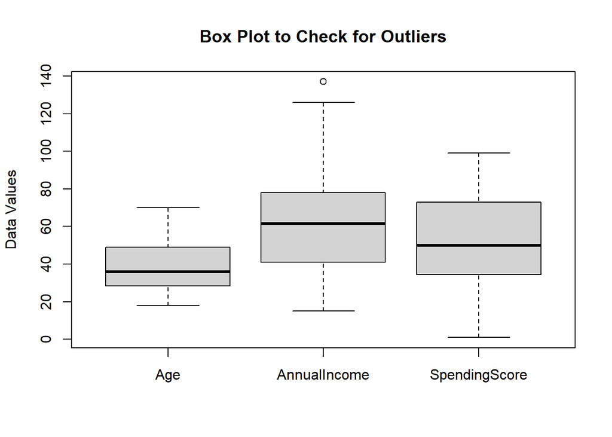

```r
numeric_data <- mall[,sapply(mall, is.numeric)]
boxplot(numeric_data,
        main="Box Plot to Check for Outliers",
          ylab="Data Values")
```

from the box plot we can see that there is an outlier in annual income since,we have one outlier in annual income,we neglect it as it may be the person with higher annual income.

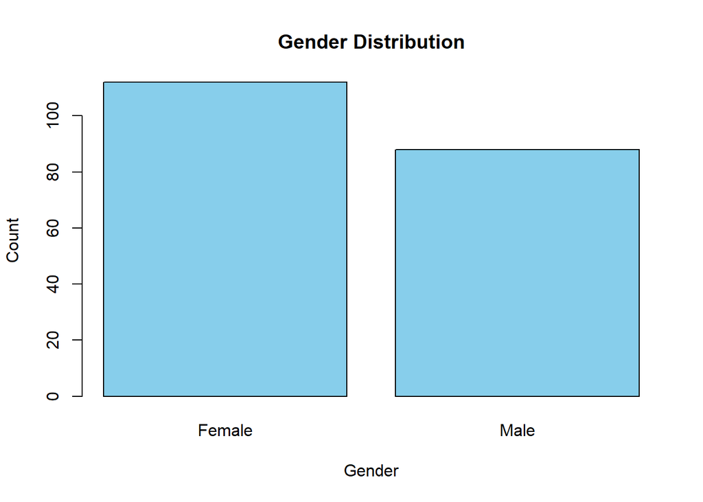

```r
gender_counts <- table(mall$Gender)
barplot(gender_counts,
        main = "Gender Distribution",
        xlab = "Gender",
        ylab = "Count",
        col = "skyblue",  # Bar color
        names.arg = names(gender_counts))
```

from the results we see that females are more than males

Calculate the kernel density estimate

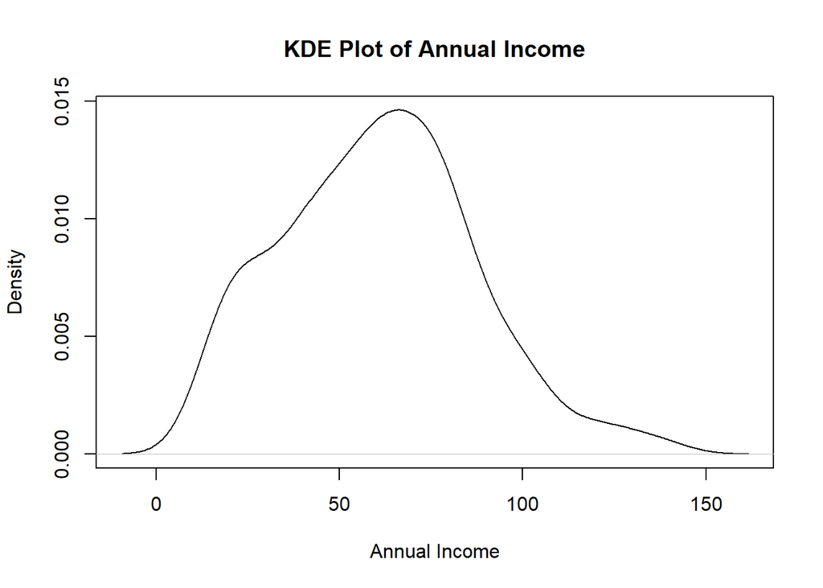

```r
density_est <- density(mall$AnnualIncome)

# Create a KDE plot using the plot() function
plot(density_est,
     main = "KDE Plot of Annual Income",
     xlab = "Annual Income",
     ylab = "Density")
```

The data is most concentrated at 60 which is the peak, the tail is from 120 to 150 where data are less concentrated.

Lets see a scattered plot Scatter plot for the Annual Income & SpendingScore by gender

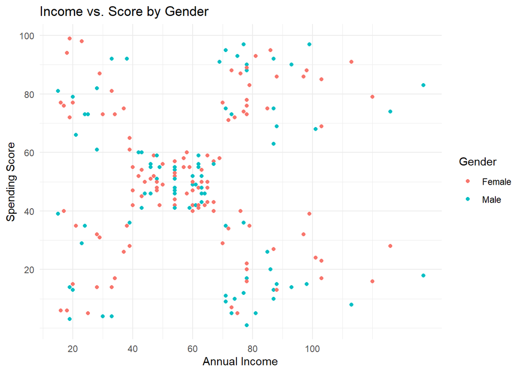

```r
ggplot(mall, aes(x = AnnualIncome, y = SpendingScore, color = Gender)) +
  geom_point() +
  labs(title = "Income vs. Score by Gender", x = "Annual Income", y = "Spending Score") +
  theme_minimal() +
  scale_x_continuous(breaks = seq(20, 100, by = 20)) +
  scale_y_continuous(breaks = seq(20, 100, by = 20))
```

#scatter plot for age and spending score

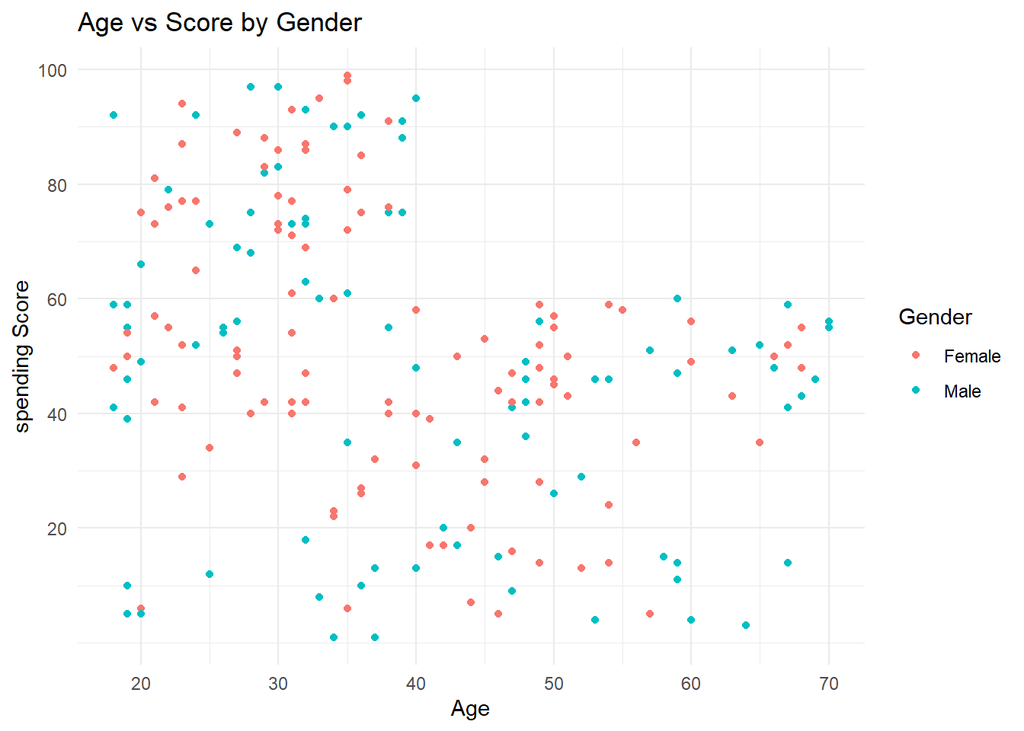

```r
ggplot(mall, aes(x= Age, y=SpendingScore,colour=Gender))+
  geom_point() +
  labs(title= "Age vs Score by Gender", x = "Age", y = "spending Score") +
  theme_minimal () +
  scale_x_continuous(breaks = seq(10, 100, by = 10)) +
  scale_y_continuous(breaks = seq(20, 100, by = 20))
```

We interpret that the age (40-60) of having spending score around (20-60), the age (20-40) of having higher spending score around (40-100) and the age (60-70) of having balanced spending score around (40-60) respectively .

DATA PREPROCESSING

changing gender to 1 and 0 male = 1 female is 0

```r
mall$Gender <- ifelse(mall$Gender =="Male", 1, 0)
```

Variables often have different units and scales. For example, “AnnualIncome” might be in thousands of dollars, while “SpendingScore” could be on a scale from 0 to 100. Scaling ensures that variables are on a similar scale, making it easier to compare and analyze them.

```r
scale_col <- c("AnnualIncome", "SpendingScore")
mall[scale_col] <- scale(mall[scale_col])
head(mall,5)
```

```
## # A tibble: 5 x 4
##   Gender   Age AnnualIncome SpendingScore
##    <dbl> <dbl>        <dbl>         <dbl>
## 1      1    19        -1.73        -0.434
## 2      1    21        -1.73         1.19
## 3      0    20        -1.70        -1.71
## 4      0    23        -1.70         1.04
## 5      0    31        -1.66        -0.395
```

Decision Steps: Data Analysis: Analyze the customer data, including annual income and spending score, to understand the distribution and characteristics of the customer base. Segmentation Method: Decide on a segmentation method. In this case, the business will use K-means clustering to group customers based on their annual income and spending score

we will use our target features which is annual income and spending score

```r
new_mall = mall[3:4]
```

Number of Clusters: Decide on the number of clusters (segments) to create. For this, i will run the Elbow Method to determine the optimal number of clusters.

```r
wcss <- numeric(10)  # Initialize a vector to store WCSS values
for (i in 1:10) {
  kmeans_model <- kmeans(new_mall, centers = i)
  wcss[i] <- kmeans_model$tot.withinss
}
wcss
```

```
##  [1] 398.00000 275.03371 156.91549 108.37671  65.24057  55.09894  47.42088
##  [8]  44.56943  41.01411  37.27701
```

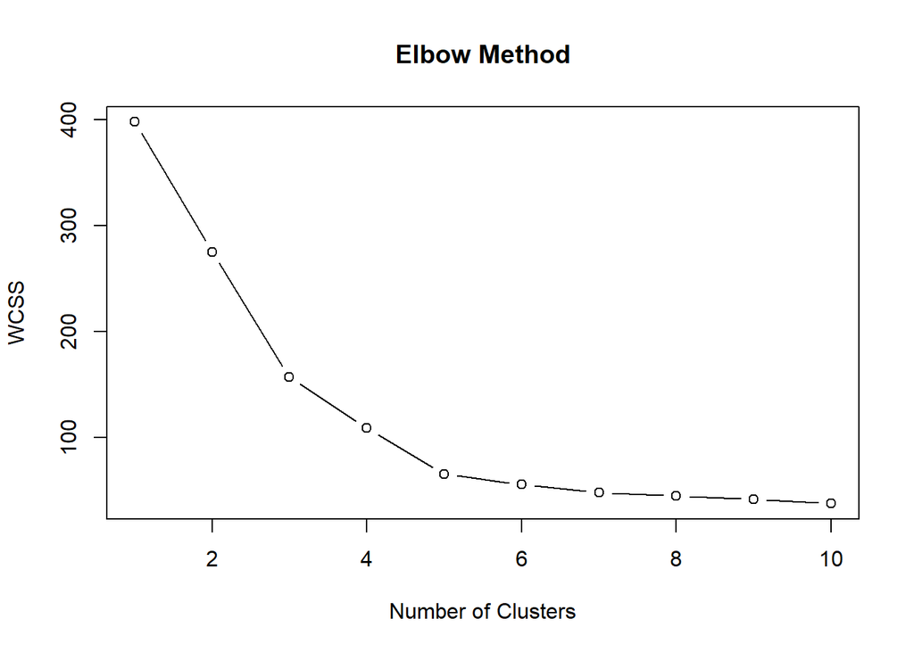

```r
plot(1:10, wcss, type = "b", main = "Elbow Method", xlab = "Number of Clusters", ylab = "WCSS")
```

Another method to check the accuracy of the k-means

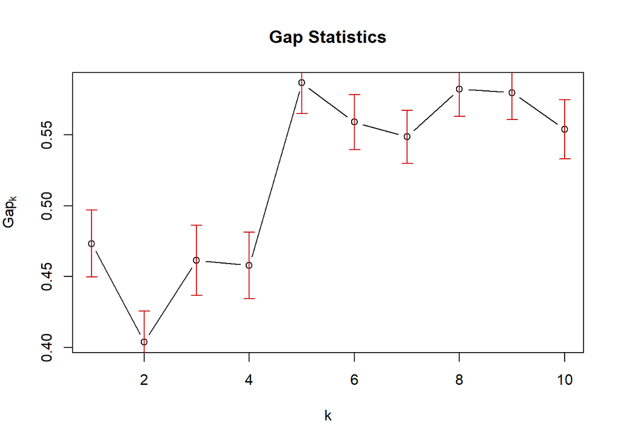

```r
gap_stat <- clusGap(new_mall, FUN = kmeans, nstart = 25, K.max = 10)
plot(gap_stat, main = "Gap Statistics")
```

Want to be sure of our cluster

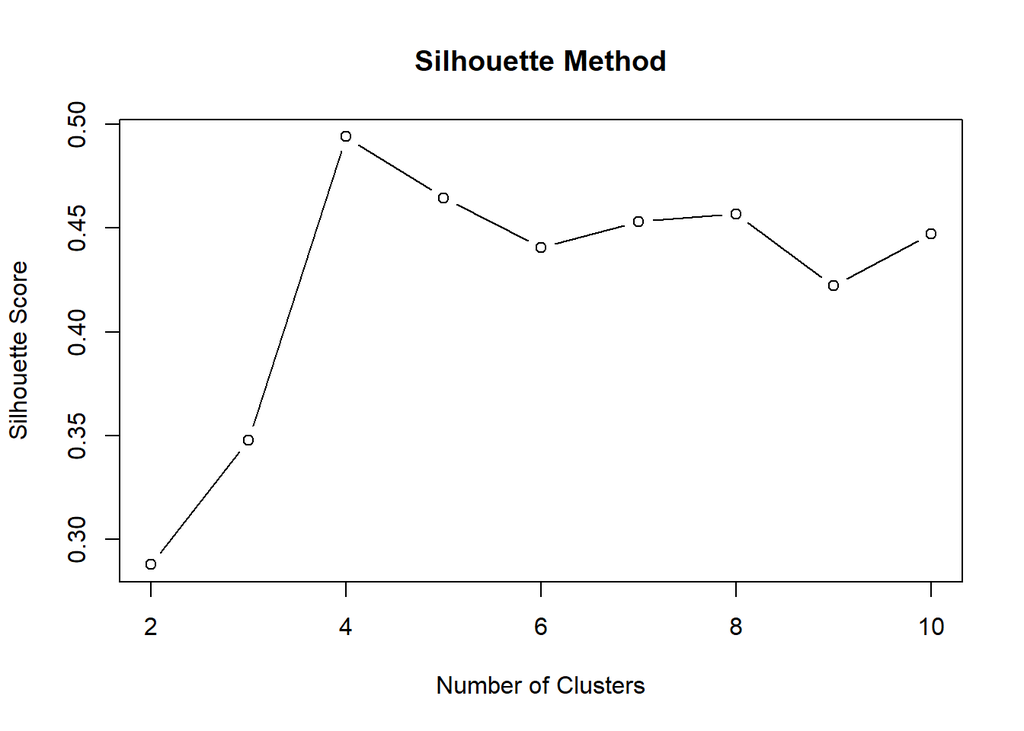

```r
silhouette_scores <- numeric(10)  # Initialize a vector to store silhouette scores
for (i in 2:10) {
  kmeans_model <- kmeans(new_mall, centers = i)
  silhouette_scores[i] <- cluster.stats(dist(new_mall), kmeans_model$cluster)$avg.silwidth
}
plot(2:10, silhouette_scores[2:10], type = "b", main = "Silhouette Method", xlab = "Number of Clusters", ylab = "Silhouette Score")
```

```r
optimal_clusters = 5
kmeans_model <- kmeans(new_mall, centers = optimal_clusters)
print(kmeans_model)
```

```
## K-means clustering with 5 clusters of sizes 81, 39, 23, 22, 35
##
## Cluster means:
##   AnnualIncome SpendingScore
## 1   -0.2004097   -0.02638995
## 2    0.9891010    1.23640011
## 3   -1.3042458   -1.13411939
## 4   -1.3262173    1.12934389
## 5    1.0523622   -1.28122394
##
## Clustering vector:
##   [1] 3 4 3 4 3 4 3 4 3 4 3 4 3 4 3 4 3 4 3 4 3 4 3 4 3 4 3 4 3 4 3 4 3 4 3 4 3
##  [38] 4 3 4 3 4 3 1 3 4 1 1 1 1 1 1 1 1 1 1 1 1 1 1 1 1 1 1 1 1 1 1 1 1 1 1 1 1
##  [75] 1 1 1 1 1 1 1 1 1 1 1 1 1 1 1 1 1 1 1 1 1 1 1 1 1 1 1 1 1 1 1 1 1 1 1 1 1
## [112] 1 1 1 1 1 1 1 1 1 1 1 1 2 5 2 1 2 5 2 5 2 1 2 5 2 5 2 5 2 5 2 1 2 5 2 5 2
## [149] 5 2 5 2 5 2 5 2 5 2 5 2 5 2 5 2 5 2 5 2 5 2 5 2 5 2 5 2 5 2 5 2 5 2 5 2 5
## [186] 2 5 2 5 2 5 2 5 2 5 2 5 2 5 2
##
## Within cluster sum of squares by cluster:
## [1] 14.485632 19.655252  7.577407  5.217630 18.304646
##  (between_SS / total_SS =  83.6 %)
##
## Available components:
##
## [1] "cluster"      "centers"      "totss"        "withinss"     "tot.withinss"
## [6] "betweenss"    "size"         "iter"         "ifault"
```

```r
# Run K-means clustering with the chosen number of clusters
final_kmeans_model <- kmeans(new_mall, centers = optimal_clusters)
# Get cluster assignments for each data point
cluster_assignments <- final_kmeans_model$cluster
##add the predicted values to the features
new_mall$cluster <- cluster_assignments
```

Visualize the model

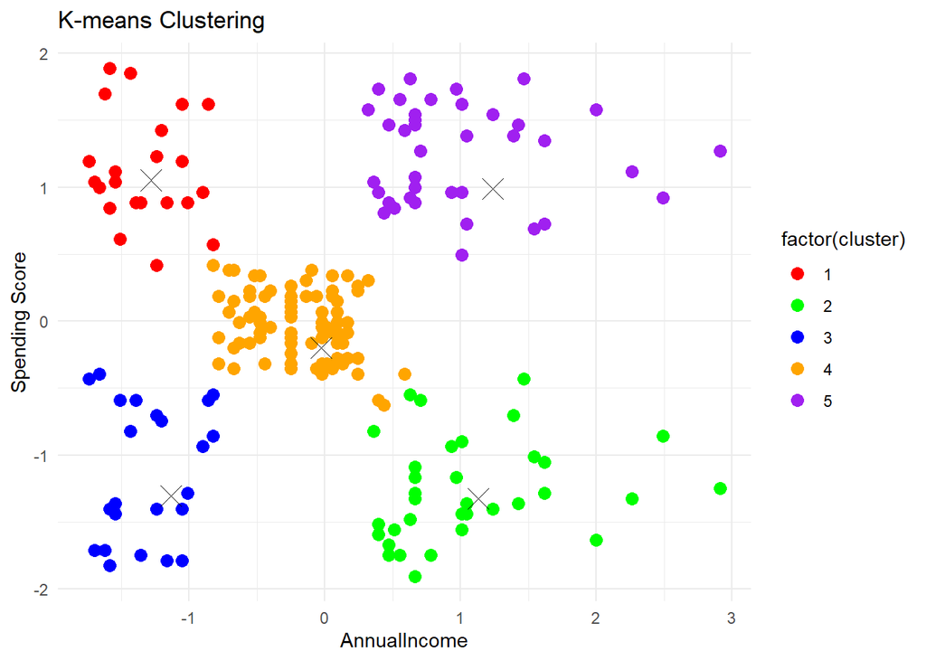

```r
centroids <- aggregate(new_mall[c("SpendingScore", "AnnualIncome")], by = list(cluster = cluster_assignments), FUN = mean)
clr <- c("red", "green", "blue", "orange", "purple")
# Create a scatter plot of clusters with centroids
ggplot(new_mall, aes(x = AnnualIncome, y = SpendingScore, color = factor(cluster))) +
  geom_point(size = 3) +
  geom_point(data = centroids, aes(x = SpendingScore, y = AnnualIncome), color = "black", size = 5, shape = 4) +
  labs(title = "K-means Clustering", x = "AnnualIncome", y = "Spending Score") +
  scale_color_manual(values = clr) +  # Use the same cluster colors as needed
  theme_minimal()
```

Now is to select the customers based on customer ID for targeted marketing

```r
combined_data <- cbind(mall_new,new_mall)
```

now filter customers in cluster 1

```r
cluster_1_customers <- combined_data %>%
  filter(cluster == 1)
head(cluster_1_customers,5)
```

```
##   CustomerID Gender Age AnnualIncome SpendingScore cluster
## 1       0002   Male  21    -1.734646     1.1927111       1
## 2       0004 Female  23    -1.696572     1.0378135       1
## 3       0006 Female  22    -1.658498     0.9990891       1
## 4       0008 Female  23    -1.620425     1.6961281       1
## 5       0010 Female  30    -1.582351     0.8441916       1
```

```r
#cluster 1 is target for discount
cluster_2_customers <- combined_data %>%
  filter(cluster == 2)
head(cluster_2_customers,5)
```

```
##   CustomerID Gender Age AnnualIncome SpendingScore cluster
## 1       0125 Female  23    0.3594175     -0.820957       2
## 2       0129   Male  59    0.3974914     -1.517996       2
## 3       0131   Male  47    0.3974914     -1.595445       2
## 4       0135   Male  20    0.4736391     -1.750342       2
## 5       0137 Female  44    0.4736391     -1.672893       2
```

```r
#cluster 2 is target for promotions
cluster_3_customers <- combined_data %>%
  filter(cluster == 3)
head(cluster_3_customers,5)
```

```
##   CustomerID Gender Age AnnualIncome SpendingScore cluster
## 1       0001   Male  19    -1.734646    -0.4337131       3
## 2       0003 Female  20    -1.696572    -1.7116178       3
## 3       0005 Female  31    -1.658498    -0.3949887       3
## 4       0007 Female  35    -1.620425    -1.7116178       3
## 5       0009   Male  64    -1.582351    -1.8277910       3
```

```r
#cluster 3 is target for promotions
cluster_4_customers <- combined_data %>%
  filter(cluster == 4)
head(cluster_4_customers,5)
```

```
##   CustomerID Gender Age AnnualIncome SpendingScore cluster
## 1       0044 Female  31   -0.8208730     0.4182234       4
## 2       0047 Female  50   -0.7827991     0.1858770       4
## 3       0048 Female  27   -0.7827991    -0.1239180       4
## 4       0049 Female  29   -0.7827991    -0.3175400       4
## 5       0050 Female  31   -0.7827991    -0.3175400       4
```

```r
#cluster 4 is target for premium products
cluster_5_customers <- combined_data %>%
  filter(cluster == 5)
head(cluster_5_customers,5)
```

```
##   CustomerID Gender Age AnnualIncome SpendingScore cluster
## 1       0124   Male  39    0.3213436     1.5799549       5
## 2       0126 Female  31    0.3594175     1.0378135       5
## 3       0128   Male  40    0.3974914     1.7348525       5
## 4       0130   Male  38    0.3974914     0.9603648       5
## 5       0132   Male  39    0.3974914     0.9603648       5
```

```r
#cluster 5 is target for promotions
```

There are other ways to promote your business through strategized marketing which i might not be able to list them all here.